# Practica Calificada 3

# Desarrollo de Preguntas

#1.Pruebe la hipótesis de que la variable “Pregnancies” tiene distribución Poisson con la función poisdisp.test

Representación gráfica de la variable Target “Pregnancies

```r
par(mfrow=c(1,2))
str(bd_diabetes)
```

```
#> tibble [768 × 9] (S3: tbl_df/tbl/data.frame)
#>  $ Pregnancies             : num [1:768] 6 1 8 1 0 5 3 10 2 8 ...
#>  $ Glucose                 : num [1:768] 148 85 183 89 137 116 78 115 197 125 ...
#>  $ BloodPressure           : num [1:768] 72 66 64 66 40 74 50 0 70 96 ...
#>  $ SkinThickness           : num [1:768] 35 29 0 23 35 0 32 0 45 0 ...
#>  $ Insulin                 : num [1:768] 0 0 0 94 168 0 88 0 543 0 ...
#>  $ BMI                     : num [1:768] 33.6 26.6 23.3 28.1 43.1 25.6 31 35.3 30.5 0 ...
#>  $ DiabetesPedigreeFunction: num [1:768] 0.627 0.351 0.672 0.167 2.288 ...
#>  $ Age                     : num [1:768] 50 31 32 21 33 30 26 29 53 54 ...
#>  $ Outcome                 : num [1:768] 1 0 1 0 1 0 1 0 1 1 ...
```

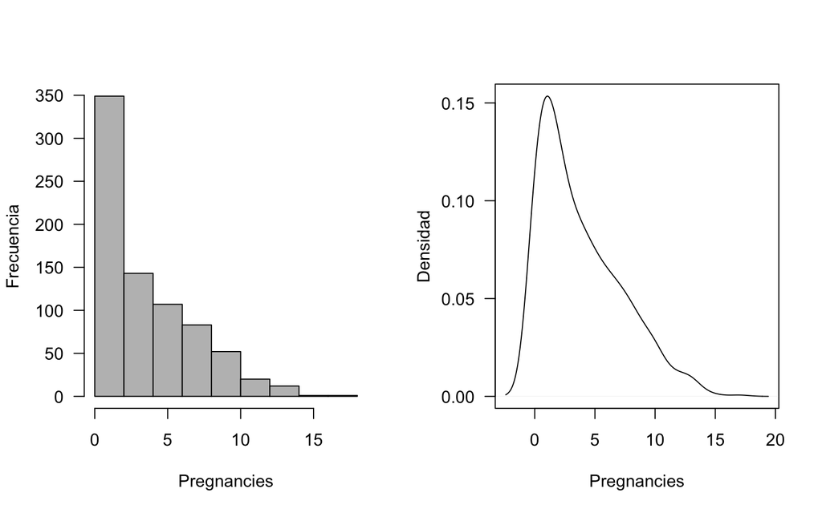

```r
hist(as.numeric(bd_diabetes$Pregnancies), xlab = "Pregnancies", ylab = "Frecuencia", las=1, main = "", col = "gray")
plot(density(as.numeric(bd_diabetes$Pregnancies)), xlab = "Pregnancies", ylab = "Densidad", las=1, main = "")
```

Interpretación :Gráficamente se puede apreciar que la variable “Pregnancies” tiene gran acumulación de ceros en sus resultados. En este sentido, se puede decir que los datos muestran una distribución asimétrica con sesgo positivo.

Prueba de hipótesis distribución Poisson

- $H0$: el número de mujeres embarazadas en un espacio de tiempo sigue una distribución Poisson.
- $H1$: el número de mujeres embarazadas en un espacio de tiempo no sigue una distribución Poisson.

```r
res1<-pois.test(bd_diabetes$Pregnancies)
res1
```

```
#> [1] 38.24396  0.00000
```

Interpretación: A un nivel de 0.05 existe evidencia para rechazar la hipótesis nula. En este sentido, la variable “Pregnancies” no sigue una distribución de poisson.

Prueba de hipótesis para la dispersión presente en los valores

- $H0$: La variable “Pregnancies” no presenta dispersión.
- $H1$: La variable “Pregnancies” presenta alta/baja dispersión.

```r
res2<-poisdisp.test(as.numeric(bd_diabetes$Pregnancies),"over",logged = FALSE)
res2
```

```
#>     stat  p-value
#> 38.19353  0.00000
```

Interpretación: A un nivel de 0.05 existe evidencia para rechazar la hipótesis nula. En este sentido, la variable “Pregnancies” presenta sobre dispersión. Ello se puede asociar a la canidad de ceros existente.

#2.Ejecute la regresión poisson para Pregnancies con la data training.

```r
m1 <- glm(as.numeric(Pregnancies) ~., family="poisson", data=training_set)
m1
```

```
#>
#> Call:  glm(formula = as.numeric(Pregnancies) ~ ., family = "poisson",
#>     data = training_set)
#>
#> Coefficients:
#>              (Intercept)                   Glucose             BloodPressure
#>                0.2273910                -0.0013115                 0.0007475
#>            SkinThickness                   Insulin                       BMI
#>                0.0002585                -0.0003632                 0.0023511
#> DiabetesPedigreeFunction                       Age                   Outcome
#>               -0.1398452                 0.0312025                 0.2914168
#>
#> Degrees of Freedom: 612 Total (i.e. Null);  604 Residual
#> Null Deviance:       1895
#> Residual Deviance: 1429  AIC: 3081
```

Para realizar una prueba de bondad de ajuste para el modelo general podemos hacer uso de lo resultados de Desvianza

Prueba de hipótesis bondad de ajuste

- $H0$: El modelo de Poisson es apropiado.
- $H1$: El modelo de Poisson no es apropiado

```r
with(m1, cbind(res.deviance = deviance, df = df.residual,
               p = pchisq(deviance, df.residual, lower.tail=FALSE)))
```

```
#>      res.deviance  df            p
#> [1,]     1429.363 604 9.506584e-69
```

Interpretación : A un nivel de significancia del 0.05 se rechaza la Ho. Es decir, el modelo Poisson no es apropiado,

#3. Aplique 10-fold cross validation para calcular el valor de MSE con la data training.

Se emplea la función cv.glm() para la validación, empleando en este caso k=10

```r
set.seed(1)
cv_error <- cv.glm(data = training_set, glmfit =m1 , K = 10)
cv_error$delta
```

```
#> [1] 9.629638 9.591042
```

#4.¿Qué variables son significativas? Ejecute la prueba de hipótesis respectiva.

```r
summary(m1 <- glm(Pregnancies ~., family="poisson", data=training_set))
```

```
#>
#> Call:
#> glm(formula = Pregnancies ~ ., family = "poisson", data = training_set)
#>
#> Deviance Residuals:
#>     Min       1Q   Median       3Q      Max
#> -4.5575  -1.1542  -0.2116   0.8061   4.0175
#>
#> Coefficients:
#>                            Estimate Std. Error z value Pr(>|z|)
#> (Intercept)               0.2273910  0.1347345   1.688   0.0915 .
#> Glucose                  -0.0013115  0.0007533  -1.741   0.0817 .
#> BloodPressure             0.0007475  0.0011492   0.650   0.5154
#> SkinThickness             0.0002585  0.0014632   0.177   0.8598
#> Insulin                  -0.0003632  0.0002087  -1.740   0.0818 .
#> BMI                       0.0023511  0.0031576   0.745   0.4565
#> DiabetesPedigreeFunction -0.1398452  0.0702857  -1.990   0.0466 *
#> Age                       0.0312025  0.0016924  18.436  < 2e-16 ***
#> Outcome                   0.2914168  0.0482648   6.038 1.56e-09 ***
#> ---
#> Signif. codes:  0 '***' 0.001 '**' 0.01 '*' 0.05 '.' 0.1 ' ' 1
#>
#> (Dispersion parameter for poisson family taken to be 1)
#>
#>     Null deviance: 1894.9  on 612  degrees of freedom
#> Residual deviance: 1429.4  on 604  degrees of freedom
#> AIC: 3081.2
#>
#> Number of Fisher Scoring iterations: 5
```

Interpretación: A un nivel de significancia de 0,05 las variables significativas para el modelo son *DiabetesPedigreeFunction,Age Outcome*

#5. Ejecute la regresión binomial negativa para Pregnancies con la data training.

```r
m2 <- glm.nb( Pregnancies~ ., data =training_set )
```

Para realizar una prueba de bondad de ajuste para el modelo general podemos hacer uso de lo resultados de Desvianza

Prueba de hipótesis bondad de ajuste

- $H0$: El modelo de Binomial Negativa es apropiado.
- $H1$: El modelo de Binomial Negativa no es apropiado

```r
with(m2, cbind(res.deviance = deviance, df = df.residual,
               p = pchisq(deviance, df.residual, lower.tail=FALSE)))
```

```
#>      res.deviance  df           p
#> [1,]     692.6498 604 0.007054317
```

Interpretación : A un nivel de significancia del 0.05 se rechaza la Ho. Es decir, el modelo Binomial Negativa no es apropiado,

#6. Presente la MSE con la data training del punto (5)

Se emplea la función cv.glm() para la validación, empleando en este caso k=10

```r
set.seed(1)
cv_error2 <- cv.glm(data = training_set, glmfit =m2 , K = 10)
cv_error2$delta
```

```
#> [1] 11.36513 11.29454
```

#7.Ejecute la regresión inflada de ceros y compare con los resultados obtenidos anteriormente

```r
m3<-zeroinfl(Pregnancies ~ ., data =training_set , dist = "negbin")

cv_error3 <- cv.glm(data = training_set, glmfit =m3 , K = 10)
cv_error3$delta
```

```
#> [1] 10.609423  9.979425
```

```r
cv_error4 <- cv.glm(data = training_set, glmfit =m3 , K = 10)
cv_error4$delta
```

```
#> [1] 10.371871  9.987079
```

#9 Comparación de MSE de los 4 modelos analizados bajo la metodología K-fold validación cruzada

```r
res_MSE <- data.frame(
  "Modelo" = c("Poisson", "Binomial Negativo", "Cero_Inflados", "Hurdle"),
  "MSE" = c(cv_error$delta[[2]],cv_error2$delta[[2]],cv_error3$delta[[2]]
               ,cv_error4$delta[[2]]))

res_MSE
```

```
#>              Modelo       MSE
#> 1           Poisson  9.591042
#> 2 Binomial Negativo 11.294542
#> 3     Cero_Inflados  9.979425
#> 4            Hurdle  9.987079
```